# Final Assignment, Task 2

Carter Fitzgerald

2023-10-27

# Task 2: Task 2: Exploratory Data Analysis: (40 marks)

1. Find the day with the highest death toll reported across the world. Print the date and the death toll of that day.

```r
library(tidyverse)
```

```r
library(dplyr)
library(Metrics)
library(modeest)
library(lubridate)
library(ggplot2)
library(gridExtra)
covid19_data <- read_csv("covid19_data.csv")
day_with_highest_deaths <- covid19_data %>%
  filter(CumDeaths == max(CumDeaths, na.rm = TRUE)) %>%
  select(Date, CumDeaths)

# Print the result as a sentence
cat("The day with the highest death toll reported across the world was on",
    format(day_with_highest_deaths$Date, format = "%Y-%m-%d"),
    "with a death toll of", day_with_highest_deaths$CumDeaths)
```

```
## The day with the highest death toll reported across the world was on 5/05/2020 with a death toll of 68934
```

2. Build a graph to show how the cumulative data of (Infected Cases, Deaths, Recovered, Tests) change over the time for the whole world collectively.

   [Hint: Use geom_line as a geometry function, use log for the Y axis for better presentation, Use different colour to distinguish between new cases, deaths, and recovered]

```r
covid19_data <- read_csv("covid19_data.csv")
```

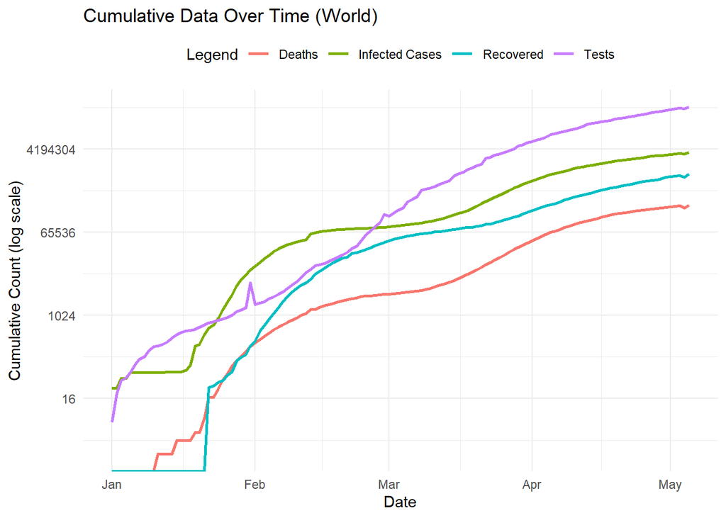

```r
covid19_data$Date <- as.Date(covid19_data$Date, format = "%d/%m/%y")

# Group and summarize the data to calculate cumulative values for each date
covid19_graph_data <- covid19_data %>%
  arrange(Date) %>%
  group_by(Date) %>%
  summarize(
    CumCases = sum(CumCases),
    CumDeaths = sum(CumDeaths),
    CumRecovered = sum(CumRecovered),
    CumTests = sum(CumTests)
  )

world_cumulative_graph <- ggplot(covid19_graph_data, aes(x = Date)) +
  geom_line(aes(y = CumCases, color = "Infected Cases"), size = 1) +
  geom_line(aes(y = CumDeaths, color = "Deaths"), size = 1) +
  geom_line(aes(y = CumRecovered, color = "Recovered"), size = 1) +
  geom_line(aes(y = CumTests, color = "Tests"), size = 1) +
  scale_y_continuous(trans = 'log2') +
  labs(
    title = "Cumulative Data Over Time (World)",
    x = "Date",
    y = "Cumulative Count (log scale)",
    color = "Legend"
  ) +
  theme_minimal() +
  theme(legend.position = "top")
# Display the graph
print(world_cumulative_graph)
```

3. Extract the data corresonding to the last day *(05/05/2020)* for all countries and save it in a separate dataframe and name it *“lastDay_data”*.

   [Hint: use filter function with Date = “2020-05-05”]

```r
# Filter the data for the last day (05/05/2020)
lastDay_data <- covid19_data %>% filter(Date == as.Date("2020-05-05", format = "%Y-%m-%d"))
```

4. Based on the data in *“lastDay_data”* dataframe, extract the corresponding records of the top 10 countries worldwide with current active cases, total confirmed cases, or fatality rate in separate dataframes (*i.e.*, top10activeW, top10casesW, top10fatalityW, top10testsMW).

   [Hint: you can use head(arranged_data, n=10) to get the top 10 records and pass the records of these 10 countries in newly created data frames]

```r
# Calculate active cases, total confirmed cases, and fatality rate
lastDay_data <- lastDay_data %>%
  mutate(
    ActiveCases = CumCases - (CumRecovered + CumDeaths),
    FatalityRate = (CumDeaths / CumCases)  # Calculate fatality rate as a percentage
  )

top10activeW <- lastDay_data %>% arrange(desc(ActiveCases))
top10casesW <- lastDay_data %>% arrange(desc(CumCases))
top10testsMW <- lastDay_data %>% arrange(desc(CumTests))
top10fatalityW <- lastDay_data %>% arrange(desc(FatalityRate))

# Use head to get the top 10 records, but limit to the number of available records
top10activeW <- head(top10activeW, n = 10)
top10casesW <- head(top10casesW, n = 10)
top10TestsMW <- head(top10testsMW, n = 10)
top10fatalityW <- head(top10fatalityW, n = 10)
```

5. Based on the data of the in *“lastDay_data”* dataframe, print total confirmed cases, death, recovered cases as well as the total tests per every `continent`.

```r
# Calculate and print totals per continent
continent_totals <- lastDay_data %>%
  group_by(Continent) %>%
  summarize(
    TotalConfirmedCases = sum(CumCases),
    TotalDeaths = sum(CumDeaths),
    TotalRecovered = sum(CumRecovered),
    TotalTests = sum(CumTests)
  )

# Print the continent totals
print(continent_totals)
```

```
## # A tibble: 6 × 5
##   Continent     TotalConfirmedCases TotalDeaths TotalRecovered TotalTests
##   <chr>                       <dbl>       <dbl>          <dbl>      <dbl>
## 1 Africa                      47124        1845          16317     618154
## 2 Asia                       567862       19991         313323    6010340
## 3 Europe                    1406374      141780         537696   17013488
## 4 North America             1290176       75981         238452    8447832
## 5 Oceania                      8579         122           7313     820684
## 6 South America              223752       11251          82246     919018
```

6. Build a graph to show the total number of cases over the time for the top 10 countries that have been obtained in question 4 (Use log transformation for the values in Y axis for better presentation).

   [Hint: first you need to get the data of the top-10 countries and then plot their lines, ie, one line per country]

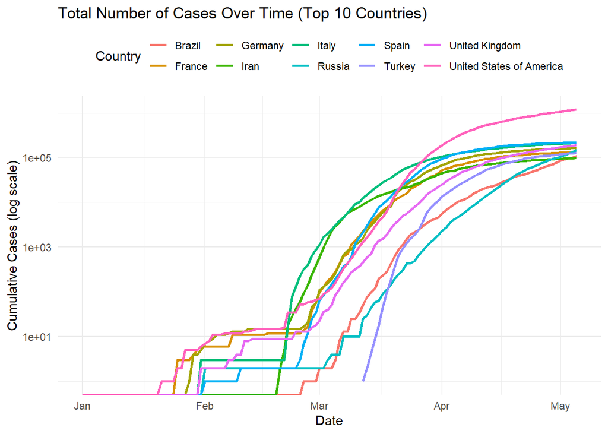

```r
# Select the top 10 countries from top10casesW dataframe
top10_countries <- top10casesW$Country

# Filter the data for the selected top 10 countries from covid19_data dataframe
top10_countries_data <- covid19_data %>% filter(Country %in% top10_countries)

# Create the graph
top10_cases_graph <- ggplot(top10_countries_data, aes(x = Date, y = CumCases, color = Country)) +
  geom_line(size = 1) +
  scale_y_log10() +  # Log transformation for the Y axis
  labs(
    title = "Total Number of Cases Over Time (Top 10 Countries)",
    x = "Date",
    y = "Cumulative Cases (log scale)",
    color = "Country"
  ) +
  theme_minimal() +
  theme(legend.position = "top")

# Display the graph
print(top10_cases_graph)
```

7. Build a graph for the top 10 countries with current highest active cases which was obtained previously in question 4. The graph should have one sub-graph (*i.e.*, using facet function) for each of these countries, every sub-graph should show how the new cases, new deaths, and new recovered cases were changing over the time (Use log for Y axis for better presentation, Use different colour to distinguish between new cases, deaths, and recovered).

   [hint: geom_line function with date on x_axis and each of the values of the variables in y_axis]

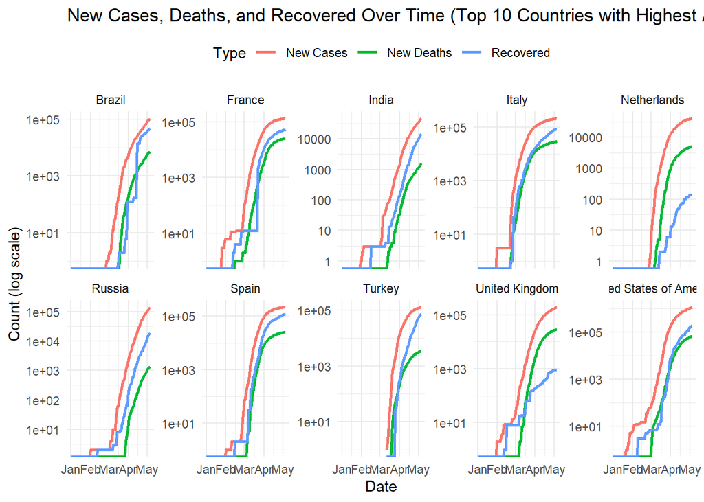

```r
# Select the top 10 countries with the highest active cases from top10activeW dataframe
top10_countries <- top10activeW$Country

# Filter the data for the selected top 10 countries from covid19_data dataframe
top10_countries_data <- covid19_data %>% filter(Country %in% top10_countries)

# Create the graph
active_cases_graph <- ggplot(top10_countries_data, aes(x = Date)) +
  geom_line(aes(y = CumCases, color = "New Cases"), size = 1) +
  geom_line(aes(y = CumDeaths, color = "New Deaths"), size = 1) +
  geom_line(aes(y = CumRecovered, color = "Recovered"), size = 1) +
  scale_y_log10() +  # Log transformation for the Y axis
  labs(
    title = "New Cases, Deaths, and Recovered Over Time (Top 10 Countries with Highest Active Cases)",
    x = "Date",
    y = "Count (log scale)",
    color = "Type"
  ) +
  facet_wrap(~Country, nrow = 2, scales = "free_y") +  # Create sub-graphs for each country
  theme_minimal() +
  theme(legend.position = "top")

# Display the graph
print(active_cases_graph)
```

8. Build a graph for the top 10 countries with current highest total tests per one million of the population which was obtained previously in question 4. This graph should present total number of infected cases, total tests so far, and the total tests per million of the population for each country.

   [hint: you can use bar chart to achieve this task]

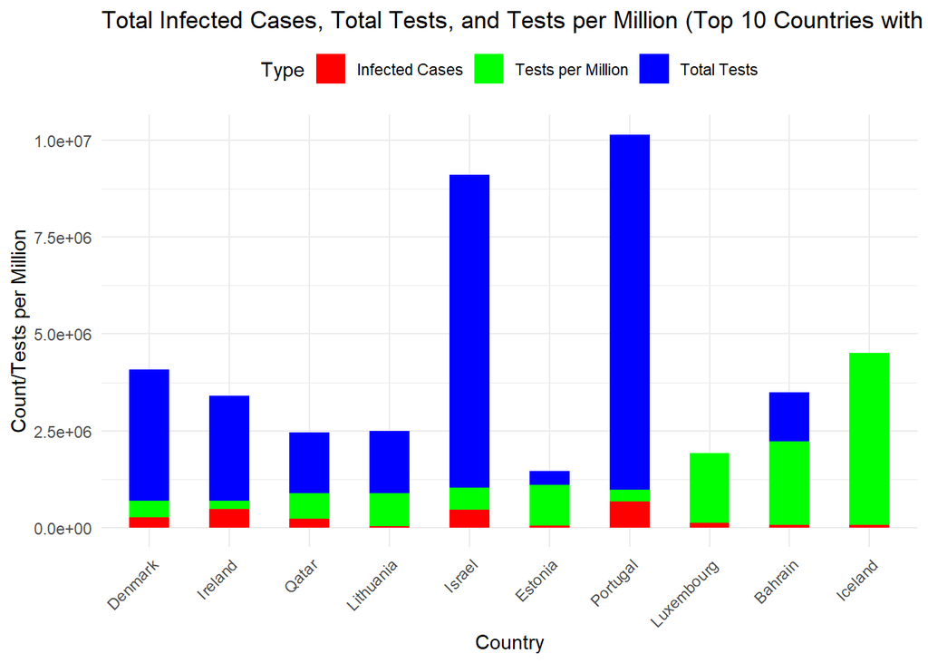

```r
# Sort the lastDay_data dataframe by Tests_1M_Pop in descending order and select the top 10 rows
top10testsMW <- lastDay_data %>% arrange(desc(Tests_1M_Pop)) %>% head(10)

# Filter the data for the selected top 10 countries from covid19_data dataframe
top10_countries_data <- covid19_data %>% filter(Country %in% top10testsMW$Country)

# Create the graph
tests_per_million_graph <- ggplot(top10_countries_data, aes(x = reorder(Country, Tests_1M_Pop))) +
  geom_bar(aes(y = CumTests, fill = "Total Tests"), stat = "identity", width = 0.5) +
  geom_bar(aes(y = Tests_1M_Pop, fill = "Tests per Million"), stat = "identity", width = 0.5) +
  geom_bar(aes(y = CumCases, fill = "Infected Cases"), stat = "identity", width = 0.5) +
  scale_fill_manual(values = c("Infected Cases" = "red", "Total Tests" = "blue", "Tests per Million" = "green")) +
  labs(
    title = "Total Infected Cases, Total Tests, and Tests per Million (Top 10 Countries with Highest Tests per Million)",
    x = "Country",
    y = "Count/Tests per Million",
    fill = "Type"
  ) +
  theme_minimal() +
  theme(legend.position = "top", axis.text.x = element_text(angle = 45, hjust = 1))

# Display the graph
print(tests_per_million_graph)
```

9. Build a graph to present the statistics total, average, median of confirmed cases of the continents. ( you may use log for Y axis for better presentation, Use Continent in the legend, make sure x-axis labels does not overlap).

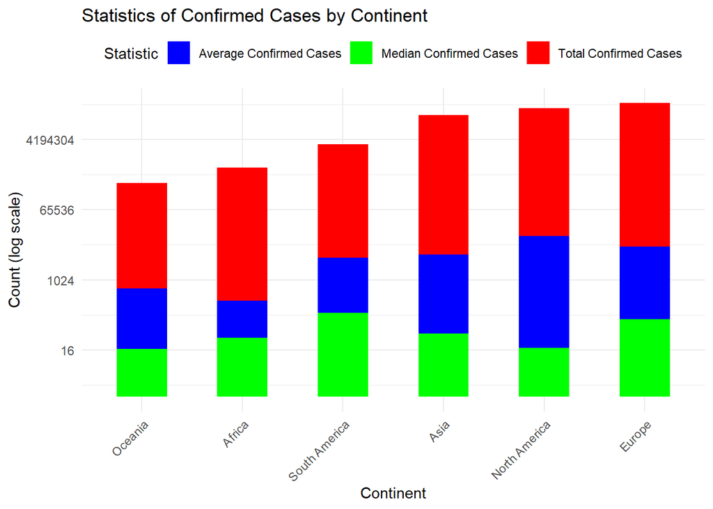

```r
# Calculate total, average, and median confirmed cases for each continent
continent_stats <- covid19_data %>%
  group_by(Continent) %>%
  summarize(
    TotalConfirmed = sum(CumCases),
    AverageConfirmed = mean(CumCases),
    MedianConfirmed = median(CumCases)
  )

# Create a graph
continent_stats_graph <- ggplot(continent_stats, aes(x = reorder(Continent, TotalConfirmed))) +
  geom_bar(aes(y = TotalConfirmed, fill = "Total Confirmed Cases"), stat = "identity", width = 0.5) +
  geom_bar(aes(y = AverageConfirmed, fill = "Average Confirmed Cases"), stat = "identity", width = 0.5) +
  geom_bar(aes(y = MedianConfirmed, fill = "Median Confirmed Cases"), stat = "identity", width = 0.5) +
  scale_fill_manual(values = c("Total Confirmed Cases" = "red", "Average Confirmed Cases" = "blue", "Median Confirmed Cases" = "green")) +
  labs(
    title = "Statistics of Confirmed Cases by Continent",
    x = "Continent",
    y = "Count (log scale)",
    fill = "Statistic"
  ) +
  scale_y_continuous(trans = 'log2') +  # Log scale for Y axis
  theme_minimal() +
  theme(legend.position = "top", axis.text.x = element_text(angle = 45, hjust = 1))

# Display the graph
print(continent_stats_graph)
```

10. Based on the data of the *“lastDay_data”* dataframe, list the top 2-countries of each continent that report the highest death toll.

```r
# List the top 2 countries with the highest death toll for each continent
top2_death_by_continent <- lastDay_data %>%
  arrange(Continent, desc(CumDeaths)) %>%
  group_by(Continent) %>%
  slice_head(n = 2)

# View the result
top2_death_by_continent
```

```
## # A tibble: 12 × 24
## # Groups:   Continent [6]
##    Code  Date       Country      Continent NewCases NewDeaths Recovered NewTests
##    <chr> <date>     <chr>        <chr>        <dbl>     <dbl>     <dbl>    <dbl>
##  1 DZA   2020-05-05 Algeria      Africa         174         2        69        0
##  2 EGY   2020-05-05 Egypt        Africa         348         7        98        0
##  3 IRN   2020-05-05 Iran         Asia          1223        74      1096    11255
##  4 CHN   2020-05-05 China        Asia             2         0        78        0
##  5 ITA   2020-05-05 Italy        Europe        1221       195      2352    55263
##  6 GBR   2020-05-05 United King… Europe        3985       288        16    69839
##  7 USA   2020-05-05 United Stat… North Am…    22593      1252      2611        0
##  8 CAN   2020-05-05 Canada       North Am…     1298       172       976    21199
##  9 AUS   2020-05-05 Australia    Oceania         24         0        88    14542
## 10 NZL   2020-05-05 New Zealand  Oceania          2         0        14        0
## 11 BRA   2020-05-05 Brazil       South Am…     6633       296      2406        0
## 12 ECU   2020-05-05 Ecuador      South Am…     2343         5         0        0
## # ℹ 16 more variables: Population <dbl>, GDP <dbl>, GDPCapita <dbl>,
## #   Month <chr>, Week <dbl>, CumCases <dbl>, CumDeaths <dbl>,
## #   CumRecovered <dbl>, CumTests <dbl>, Active <dbl>, FatalityRate <dbl>,
## #   Cases_1M_Pop <dbl>, Deaths_1M_Pop <dbl>, Recovered_1M_Pop <dbl>,
## #   Tests_1M_Pop <dbl>, ActiveCases <dbl>
```

**Task 2 final Report**: For each of the above, ensure that you have extracted the generated statistics (eg, numerical values) or the visualizations (eg, graphs) alongside with your description as output of each component in the knitted report. The marking will be conducted based on the description and validity of these quantitative and qualitative components of the analysis.